# Penggerombolan Kabupaten/Kota di Provinsi Banten dan DKI Jakarta Berdasarkan 8 Standar Nasional Pendidikan

Author(s):

- M Raziv Zulfikar

- Ferista Wahyu Saputri

- Tantri Gustina Dewi

- Aryo Seto Ramadhan

- Irpando Sagala

2022-11-28

```r
library(readxl)
library(tidyverse)
library(factoextra)
library(clValid)
library(fmsb)
```

# 1. Pendahuluan

Standar Nasional Pendidikan (SNP) merupakan kriteria minimal mengenai sistem pendidikan di seluruh wilayah Indonesia. Pemerataan kualitas pendidikan dapat dianalisis melalui pengelompokan wilayah berdasarkan capaian 8 standar nasional pendidikan.

Penelitian ini bertujuan untuk mengelompokkan kabupaten/kota di Provinsi Banten dan DKI Jakarta menggunakan metode Hierarchical Clustering dengan algoritma: - Average Linkage - Centroid Linkage

Jumlah gerombol optimal ditentukan menggunakan metode Silhouette dan dilakukan perbandingan menggunakan Cophenetic Correlation.

# 2. Data

Data yang digunakan adalah data nilai standar nasional pendidikan dengan individunya adalah sekolah dari tingkat SD sampai SMA di kabupaten/kota provinsi BANTEN DAN DKI dan peubah nya rata-rata skor 8 standar nasional pendidikan.

```r
data_raw <- read_xlsx("C:/Users/MRZ/Documents/MyProjects/NES-Clustering/data_snp.xlsx")
data_raw <- subset(data_raw, nama_provinsi != "JAWA BARAT")
head(data_raw)
```

```
## # A tibble: 6 × 14
##   nama_provinsi nama_kota       JENJANG nama_jenjang tipe_sekolah standar_isi
##   <chr>         <chr>           <chr>   <chr>               <dbl>       <dbl>
## 1 BANTEN        KABUPATEN LEBAK SD      SD/MI                   1         100
## 2 BANTEN        KABUPATEN LEBAK SD      SD/MI                   1          98
## 3 BANTEN        KABUPATEN LEBAK SD      SD/MI                   1          96
## 4 BANTEN        KABUPATEN LEBAK SD      SD/MI                   1          91
## 5 BANTEN        KABUPATEN LEBAK SD      SD/MI                   1          95
## 6 BANTEN        KABUPATEN LEBAK SD      SD/MI                   1         100
## # ℹ 8 more variables: standar_proses <dbl>, standar_kompetensi <dbl>,
## #   standar_pendidik <dbl>, standar_sarana <dbl>, standar_pengelolaan <dbl>,
## #   standar_biaya <dbl>, standar_nilai <dbl>, PERINGKAT <chr>
```

```r
variabel_snp <- c(
  "standar_isi",
  "standar_proses",
  "standar_kompetensi",
  "standar_pendidik",
  "standar_sarana",
  "standar_pengelolaan",
  "standar_biaya",
  "standar_nilai"
)

data_project <- aggregate(
  data_raw[, variabel_snp],
  by = list(
    nama_provinsi = data_raw$nama_provinsi,
    nama_kota = data_raw$nama_kota
  ),
  FUN = mean,
  na.rm = TRUE
)
head(data_project)
```

```
##   nama_provinsi                  nama_kota standar_isi standar_proses
## 1   DKI JAKARTA KABUPATEN KEPULAUAN SERIBU    96.57143       92.00000
## 2        BANTEN            KABUPATEN LEBAK    88.07040       84.38989
## 3        BANTEN       KABUPATEN PANDEGLANG    87.26316       83.26794
## 4        BANTEN           KABUPATEN SERANG    89.68070       86.07719
## 5        BANTEN        KABUPATEN TANGERANG    89.80858       86.64686
## 6        BANTEN               KOTA CILEGON    93.59596       90.32323
##   standar_kompetensi standar_pendidik standar_sarana standar_pengelolaan
## 1           91.28571         85.57143       91.14286            91.57143
## 2           84.37365         75.28881       73.35018            86.32852
## 3           83.76316         75.30383       73.60766            84.95933
## 4           86.88947         78.89123       77.13684            87.92105
## 5           87.05281         78.64686       80.26073            87.63366
## 6           90.76768         82.93939       82.09091            92.02020
##   standar_biaya standar_nilai
## 1      97.28571      94.14286
## 2      88.69495      86.25993
## 3      90.63876      85.19139
## 4      90.01404      88.26491
## 5      89.14026      88.95545
## 6      92.06061      92.32323
```

# 3. Exploratory Data Analysis

## 3.1 Statistik Deskriptif

```r
stat_snp <- data.frame(
  Minimum = apply(data_raw[, variabel_snp], 2, min),
  Rata_rata = apply(data_raw[, variabel_snp], 2, mean),
  Maksimum = apply(data_raw[, variabel_snp], 2, max),
  Simpangan_baku = apply(data_raw[, variabel_snp], 2, sd)
)
stat_snp <- t(stat_snp)
colnames(stat_snp) <- c("SI", "SPR", "SKL", "SPT", "SSP", "SPL", "SB", "SPN")
stat_snp
```

```
##                        SI        SPR       SKL       SPT       SSP        SPL
## Minimum         62.000000  62.000000  59.00000 50.000000  61.00000  53.000000
## Rata_rata       91.410262  88.619349  88.82618 80.728978  82.10127  89.770344
## Maksimum       100.000000 100.000000 100.00000 98.000000 100.00000 100.000000
## Simpangan_baku   6.159321   6.884647   6.95932  8.635719  10.78831   6.890387
##                       SB        SPN
## Minimum         53.00000  61.000000
## Rata_rata       91.05063  90.437839
## Maksimum       100.00000 100.000000
## Simpangan_baku   6.84413   6.719585
```

## 3.2 Boxplot Perbandingan Skor SNP Provinsi Banten dan DKI Jakarta

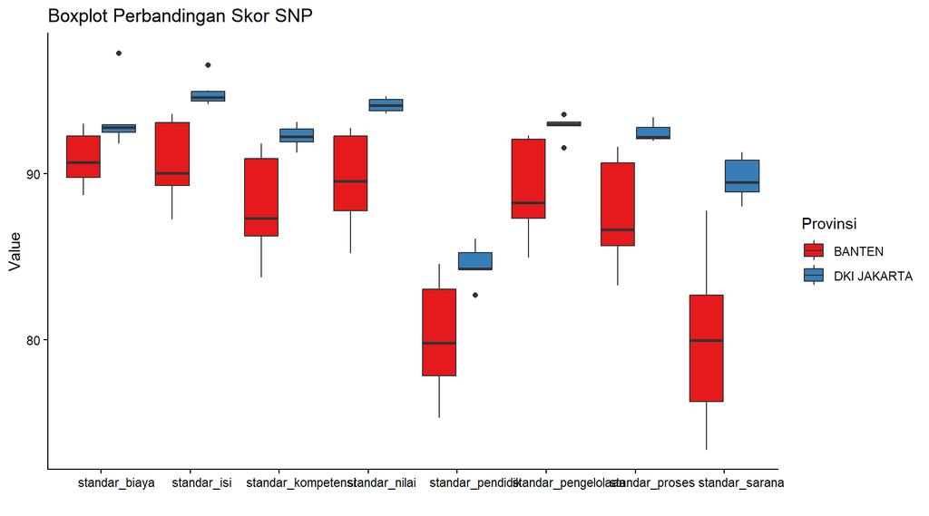

```r
data_long <- data_project %>%
  pivot_longer(
    cols = all_of(variabel_snp),
    names_to = "variable",
    values_to = "value"
  )

ggplot(data_long,
       aes(x = variable,
           y = value,
           fill = nama_provinsi)) +
  geom_boxplot(position = position_dodge(width = 0.8)) +
  theme_classic() +
  labs(
    title = "Boxplot Perbandingan Skor SNP",
    x = "",
    y = "Value",
    fill = "Provinsi"
  ) +
  theme(
    axis.text.x = element_text(angle = 0, hjust = 0.3)
  ) + scale_fill_brewer(palette = "Set1")
```

## 3.3 Boxplot Skor SNP Kota/Kabupaten di Provinsi Banten dan DKI Jakarta

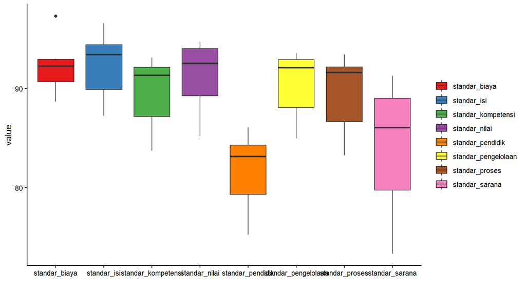

```r
ggplot(data_long,
       aes(x = variable,
           y = value,
           fill = variable)) +
  geom_boxplot() +
  theme_classic() +
  labs(
    x = "",
    y = "value"
  ) +
  theme(
    axis.text.x = element_text(angle = 0, hjust = 0.5),
    legend.title = element_blank()
  ) + scale_fill_brewer(palette = "Set1")
```

# 4. Hierarchical Clustering

```r
data_cluster <- data_project[, variabel_snp]
linkage_methods <- c("average","centroid")
hc_project_dend <- lapply(linkage_methods, function(i)
  hclust(dist(data_cluster,method = 'euclidean'),method = i)
)
```

## 4.1 Average Linkage

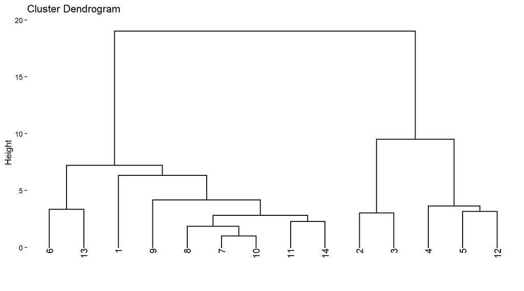

```r
fviz_dend(hc_project_dend[[1]])
```

```r
# Cophenetic Correlation
avg_coph <- cophenetic(hc_project_dend[[1]])
cor(avg_coph, dist(data_cluster, method = "euclidean"))
```

```
## [1] 0.8673443
```

## 4.2 Centroid Linkage

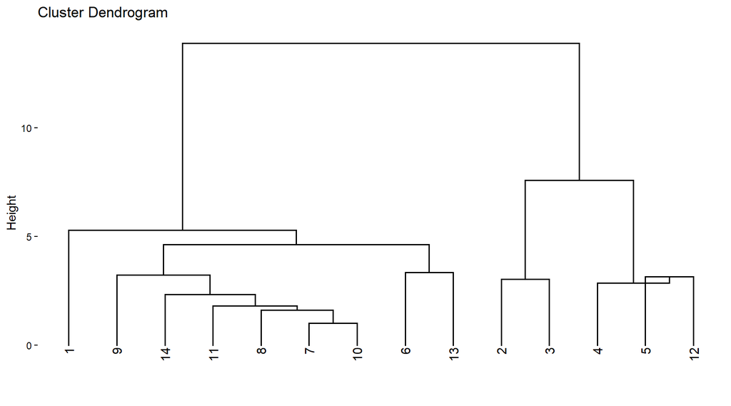

```r
fviz_dend(hc_project_dend[[2]])
```

```r
# Cophenetic Correlation
centroid_coph <- cophenetic(hc_project_dend[[2]])
cor(centroid_coph, dist(data_cluster, method = "euclidean"))
```

```
## [1] 0.8662175
```

# 5. Mencari nilai K (Silhouette Method)

## 5.1 Average Linkage

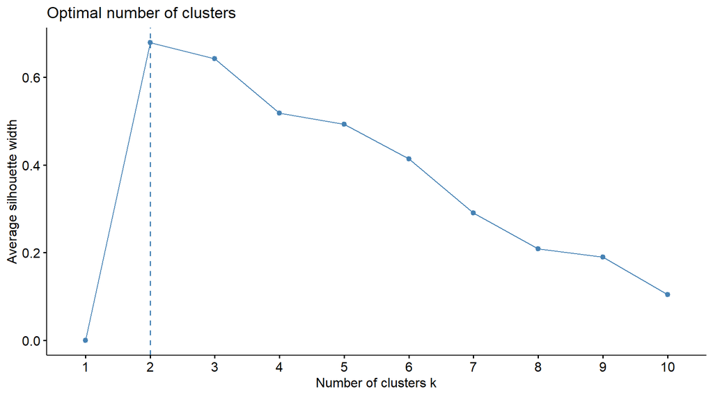

```r
fviz_nbclust(
  data_cluster,
  FUNcluster = hcut,
  method = "silhouette",
  hc_method = "average",
  hc_metric = "euclidean"
)
```

Grafik diatas menunjukkan jumlah gerombol yang paling optimal untuk average linkage dengan jarak euclidian menurut metode silhoutte adalah 2 gerombol

## 5.2 Centroid Linkage

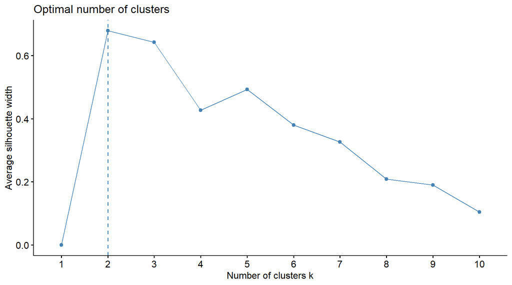

```r
fviz_nbclust(
  data_cluster,
  FUNcluster = hcut,
  method = "silhouette",
  hc_method = "centroid",
  hc_metric = "euclidean"
)
```

Grafik diatas menunjukkan jumlah gerombol yang paling optimal untuk centroid linkage dengan jarak euclidian menurut metode silhoutte adalah 2 gerombol

# 6. Penerapan Gerombol K=2

## 6.1 Average Linkage

```r
par(mfrow=c(1,1))
hc_project_average <- eclust(data_cluster,stand = TRUE,FUNcluster = "hclust",k=2,hc_method = "average",hc_metric = "euclidean",graph = F)
hc_project_average$cluster
```

```
##  [1] 1 2 2 2 2 1 1 1 1 1 1 2 1 1
```

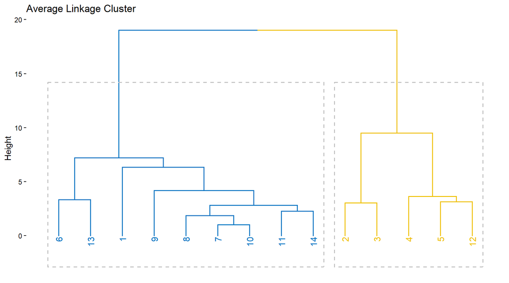

```r
fviz_dend(hc_project_dend[[1]], k = 2, k_colors = "jco", rect = T,
          main = "Average Linkage Cluster")
```

## 6.2 Centroid Linkage

```r
hc_project_centroid <- eclust(data_cluster,stand = TRUE,FUNcluster = "hclust",k=2,hc_method = "centroid",hc_metric = "euclidean",graph = F)
hc_project_centroid$cluster
```

```
##  [1] 1 2 2 2 2 1 1 1 1 1 1 2 1 1
```

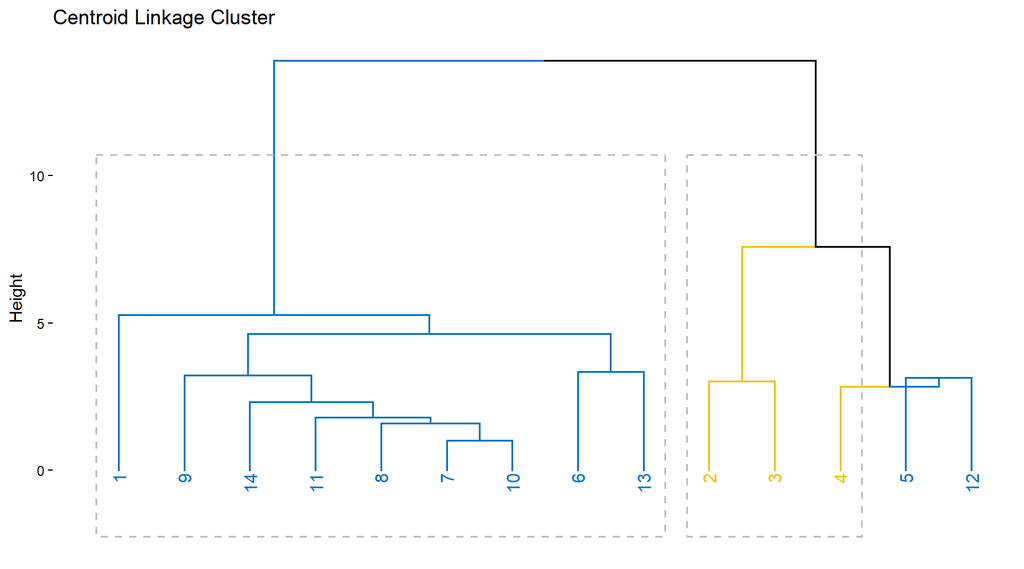

```r
fviz_dend(hc_project_dend[[2]], k = 2, k_colors = "jco", rect = T,
          main = "Centroid Linkage Cluster")
```

# 7. Cluster Plot dan Interpretasi

## 7.1 Average Linkage

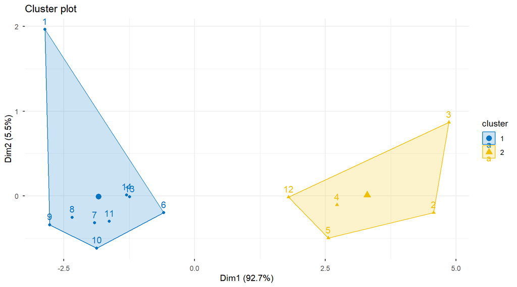

```r
fviz_cluster(hc_project_average,palette = "jco",ggtheme = theme_minimal())
```

```r
aggregate(data_cluster,by =list(gerombol=hc_project_average$cluster),
          FUN = mean)
```

```
##   gerombol standar_isi standar_proses standar_kompetensi standar_pendidik
## 1        1    94.36121       92.05486           91.94723         84.22211
## 2        2    89.01367       85.40692           85.92959         77.76267
##   standar_sarana standar_pengelolaan standar_biaya standar_nilai
## 1       88.05977            92.62715      93.12417      93.58116
## 2       76.79443            87.08708      89.84371      87.76907
```

Cluster 1 merupakan kabupaten/kota dengan keselurahan rata rata nilai 8 standar nasional yang lebih tinggi dari keseluruhan rata rata nilai 8 standar nasional pada cluster 2. Secara eksploratif pada cluster plot tidak mengindikasikan adanya gerombol yang saling tumpang tindih

## 7.2 Centroid Linkage

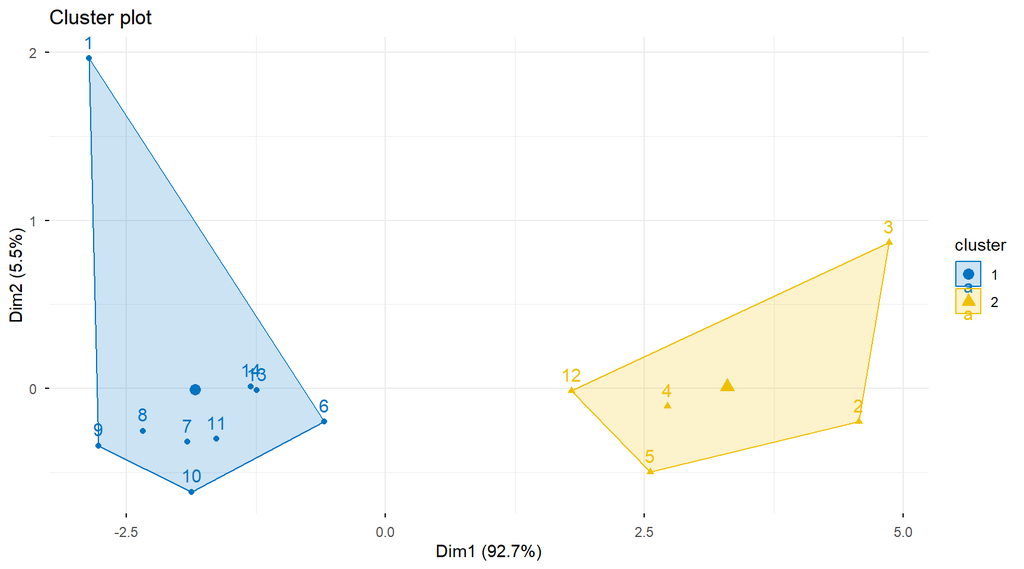

```r
fviz_cluster(hc_project_centroid,palette = "jco",ggtheme = theme_minimal())
```

```r
aggregate(data_cluster,by =list(gerombol=hc_project_centroid$cluster),
          FUN = mean)
```

```
##   gerombol standar_isi standar_proses standar_kompetensi standar_pendidik
## 1        1    94.36121       92.05486           91.94723         84.22211
## 2        2    89.01367       85.40692           85.92959         77.76267
##   standar_sarana standar_pengelolaan standar_biaya standar_nilai
## 1       88.05977            92.62715      93.12417      93.58116
## 2       76.79443            87.08708      89.84371      87.76907
```

Sama seperti Average Linkage, Cluster 1 pada Centroid Linkage merupakan kabupaten/kota dengan keselurahan rata rata nilai 8 standar nasional yang lebih tinggi dari keseluruhan rata rata nilai 8 standar nasional pada cluster 2. Cluster plot pada metode Centroid Linkage sama persis dengan Cluster plot pada Average Linkage, tidak ada indikasi gerombol yang tumpang tindih

# 8. Cluster Final

```r
cluster_final <- cutree(hc_project_average, k = 2)
data_project$cluster <- cluster_final

split(data_project$nama_kota, data_project$cluster)
```

```
## $`1`
## [1] "KABUPATEN KEPULAUAN SERIBU" "KOTA CILEGON"
## [3] "KOTA JAKARTA BARAT"         "KOTA JAKARTA PUSAT"
## [5] "KOTA JAKARTA SELATAN"       "KOTA JAKARTA TIMUR"
## [7] "KOTA JAKARTA UTARA"         "KOTA TANGERANG"
## [9] "KOTA TANGERANG SELATAN"
##
## $`2`
## [1] "KABUPATEN LEBAK"      "KABUPATEN PANDEGLANG" "KABUPATEN SERANG"
## [4] "KABUPATEN TANGERANG"  "KOTA SERANG"
```